# Meeting 20/04/2026

```python
## Load dataset and views from mongodb
dataset = fo.load_dataset("dugong")

## load the views
nc_view = dataset.load_saved_view("nc")
wp_view = dataset.load_saved_view("wp")
```

# Folder Hierarchy

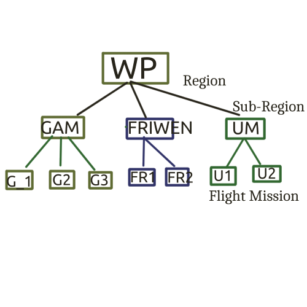

# West Papua - FLPLAN and MAN

FLPLAN stands for transects flights

MAN stands for manual flight following dugongs.

```python
print(f"Number of FLPLAN and MAN present on the WEST PAPUA dataset:")
wp_view.count_values('flight_plan')
```

```
Number of FLPLAN and MAN present on the WEST PAPUA dataset:
```

```
{'FPLAN': 31, 'MAN': 2008}
```

```python
print(f"Number of images images per flight mission WEST PAPUA:\n")
dict_print = wp_view.count_values('stratify_key')
for i,v in dict_print.items():
    print(f"{i}: {v}")
```

```
Number of images images per flight mission WEST PAPUA:

WP_FRIWEN_FRIWEN_M19: 14
WP_FRIWEN_FRIWEN_M8: 222
WP_FRIWEN_FRIWEN_M12: 204
WP_FRIWEN_FRIWEN_M11: 335
WP_GAM_GAM_M10: 26
WP_GAM_GAM_M2: 275
WP_GAM_GAM_M1: 211
WP_MANTASANDY_MANTASANDY_M5: 3
WP_UM_UM_M6: 269
WP_UM_UM_M1: 14
WP_UM_UM_M2: 9
WP_FRIWEN_FRIWEN_M53: 4
WP_UM_UM_M5: 449
WP_UM_UM_M3: 4
```

```python
print(f"Number of Images per Subregion:")
dd = wp_view.count_values("subregion")
for i,v in dd.items():
    print(f"{i}:{v}")
```

```
Number of Images per Subregion:
GAM:512
FRIWEN:779
MANTASANDY:3
UM:745
```

```python
print(f"Number of FLPLAN AND MAN per sub-region:\n")
for subregion in wp_view.distinct("subregion"):
    dict = wp_view.match(F("subregion")==subregion).count_values("flight_plan")
    print(f"{subregion}:{dict}")
```

```
Number of FLPLAN AND MAN per sub-region:

FRIWEN:{'MAN': 779}
GAM:{'MAN': 511, 'FPLAN': 1}
MANTASANDY:{'FPLAN': 3}
UM:{'MAN': 718, 'FPLAN': 27}
```

# Caroline split

two proposal of splits:

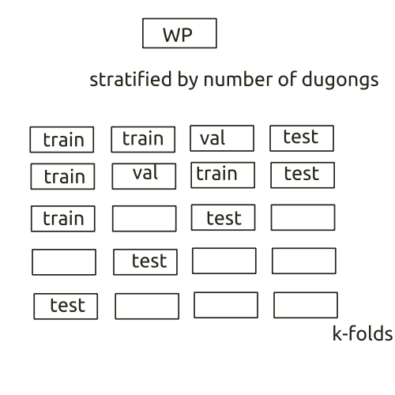

## Proposed splits:

### stratified by subregion

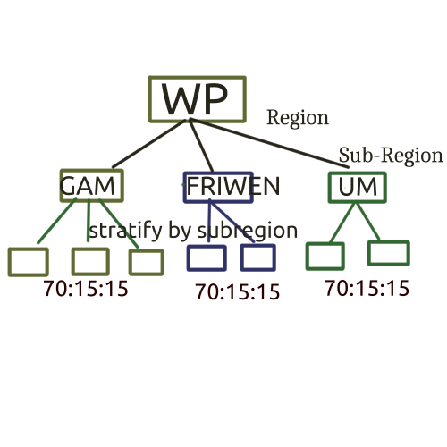

### stratified by flight

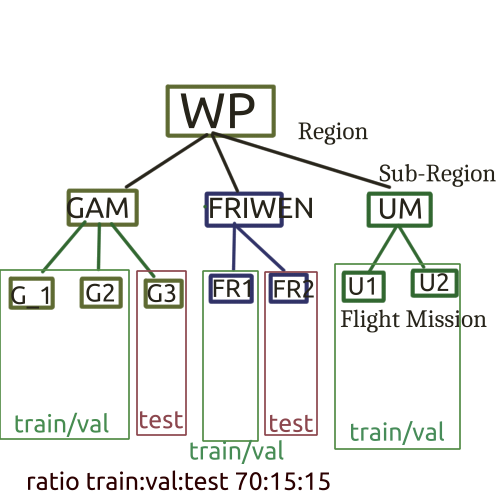

Does the same stratification should be used to train the baseline model in NC?

- Proposed split for NC.

Since NC contains only FLPLAN flights, we expect a higher diversity in terms of image characteristics. Therefore, a optimal model trained on this island should take in consideration each flight mission individually and sample train/val/test ratio from each flight mission.

```python
## dataset tagged for two different seeds
dataset.distinct("tags")
```

```
['test_29', 'test_38', 'train_29', 'train_38', 'val_29', 'val_38']
```

```python
# Example usage for first seed:
first_seed = 29
mission_df = get_mission_split_report(dataset, first_seed)
print(mission_df)
```

```
          mission  total  train  val  test  train_pct
0      FRIWEN_M11    335    228   57    50       68.1
1      FRIWEN_M12    204    144   29    31       70.6
2      FRIWEN_M19     14     11    1     2       78.6
3      FRIWEN_M53      4      3    0     1       75.0
4       FRIWEN_M8    222    159   30    33       71.6
5      Flight_195      6      5    0     1       83.3
6      Flight_196     63     47    7     9       74.6
7      Flight_197     50     31   11     8       62.0
8      Flight_198     73     48   14    11       65.8
9      Flight_199      8      4    3     1       50.0
10     Flight_200     10      8    0     2       80.0
11     Flight_205      9      8    0     1       88.9
12     Flight_207    128     90   19    19       70.3
13     Flight_209     83     58   12    13       69.9
```

[output cut: 25 more lines]

Then, all subsequent models for fine-tunning on WP should come from this special partition from NC.

Few more notes:

- Caroline send me her splitting strategy and I am able to implement her strategy, would it be worth to run models for comparison?

## Proportinal number of images and ratio for tilling scheme

At least in our validation set, the proportion of images should be similar, also on the background aspect.

- Non Maximum Supression
- Should check the end ratio of images with dugong and without it.

```python
gam_view = wp_view.match(F("subregion")=="GAM")
```

```python
print(f"Number of tiles images with dugong per region:\n")
for subregion in wp_view.distinct("subregion"):
    subregion_s = wp_view.match(F("subregion")==subregion)

    nn = subregion_s.filter_labels(
        "roi_grid",
        F("contains_dugong") == True
    ).count("roi_grid.detections")
    print(f"{subregion}:{nn}")
```

```
Number of tiles images with dugong per region:

FRIWEN:1979
GAM:1005
MANTASANDY:4
UM:1954
```

```python
dataset.distinct("tags")
```

```
['test_29', 'test_38', 'train_29', 'train_38', 'val_29', 'val_38']
```

```python
seed_list= [29,38]
for seed_number in seed_list:
    print(f"Number of Images and tiles of images at seed:{seed_number}")
    tags = [f"train_{seed_number}", f"val_{seed_number}", f"test_{seed_number}"]
    report_data=[]
    for subregion in wp_view.distinct("subregion"):
        subregion_view = dataset.match(F("subregion") == subregion)
        subregion_tiles = subregion_view.filter_labels(
                                                "roi_grid",
                                                F("contains_dugong") == True
                                            ).count("roi_grid.detections")
        train_view = subregion_view.match_tags(tags[0])
        train_tiles = train_view.filter_labels(
                                                "roi_grid",
                                                F("contains_dugong") == True
                                            ).count("roi_grid.detections")
        val_view = subregion_view.match_tags(tags[1])
        val_tiles = val_view.filter_labels(
                                                "roi_grid",
                                                F("contains_dugong") == True
                                            ).count("roi_grid.detections")
        test_view = subregion_view.match_tags(tags[2])
        test_tiles = test_view.filter_labels(
                                                "roi_grid",
                                                F("contains_dugong") == True
                                            ).count("roi_grid.detections")
        # Count samples per tag for this specific mission
        counts = {
            "subregion": subregion,
            "total": len(subregion_view),
            "total_tiles":subregion_tiles,
            "train": len(train_view),
            "train_tiles":train_tiles,
            "val":  len(val_view),
            "val_tiles":val_tiles,
            "test":  len(test_view),
            "test_tiles":test_tiles
        }
        report_data.append(counts)


    for subregion in report_data:
        for i,v in subregion.items():
            print(i,v)
        print('-'*10)

    print('-'*30)
    print(f"\n")
```

```
Number of Images and tiles of images at seed:29
subregion FRIWEN
total 779
total_tiles 1979
train 545
train_tiles 1403
val 117
val_tiles 292
test 117
test_tiles 284
----------
subregion GAM
total 512
total_tiles 1005
train 358
train_tiles 686
val 77
val_tiles 162
test 77
test_tiles 157
----------
subregion MANTASANDY
total 3
total_tiles 4
train 0
train_tiles 0
val 0
val_tiles 0
test 0
test_tiles 0
----------
subregion UM
total 745
total_tiles 1954
train 521
train_tiles 1386
val 112
val_tiles 280
test 112
test_tiles 288
```

[output cut: 31 more lines]

```
val_tiles 0
test 0
test_tiles 0
----------
subregion UM
total 745
total_tiles 1954
train 521
train_tiles 1392
val 112
val_tiles 280
test 112
test_tiles 282
----------
------------------------------
```

# Best Sample Selection

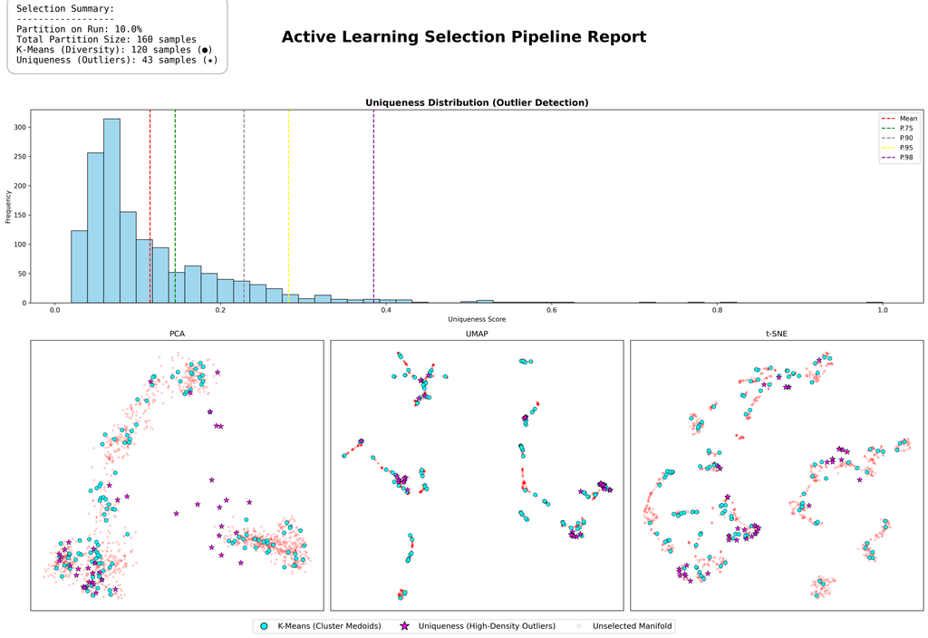

Parameters:

- Number of clusters.
- Partition percentage
- Temperature

Steps active learning selection:

1. Compute the budget for the given partition for a given ratio. Ex: 10% of training dataset with a 0.33 ratio. The ratio gives the number of uniqueness images to selected.
2. Compute Weighted Uniqueness: calculates a uniqueness score for each image based on weighted NN. "If an image is far from its $k$ neighbors in the embedding space, it is "Unique." We weight closer neighbors more heavily to identify samples that exist in low-density regions of the manifold"
3. Select the number of uniqueness images by threholding the uniqueness histogram distribution to match a given percentile.
4. Compute the resting budget to fullfill the total training partition. (total training partition - len(uniqueness) )
5. K-means clustering on latent space with cosine similarity metric. Partitioning the manifold into $K$ environmental themes.
6. To pick the most representative samples, uses a Stochastic Selection instead of picking the absolute center. It applies the Temperature-scaled softmax (T)
7. Project and visualize the report.

```python
# Stochastic Selection
# 2. Calculate L2 distances from the Centroid to all points in the cluster
dists = np.linalg.norm(embeddings[cluster_indices] - centroids[i], axis=1)

# 3. Compute Softmax-based probabilities
# use (-distances) because smaller distances should have higher probability.
# scaling by Temperature paramter stretches or flattens the probability distribution.
weights = np.exp(-dists / temperature)
probs = weights / np.sum(weights)

# 4. Stochastic Sampling
# size: Number of samples to pick (cannot exceed cluster size)
# replace=False: Ensures we pick unique images
n_to_pick = min(len(cluster_indices), c_per_cluster)
chosen_in_cluster = rng.choice(
    len(cluster_indices),
    size=n_to_pick,
    replace=False,
    p=probs
)
```

By using np.exp(-dists / T), we are modeling a Gibbs Distribution over your feature space. This is a common technique in reinforcement learning to balance "exploitation" (the center) and "exploration" (the surrounding variability).

This idea was to prevent redudancy and near-identical samples.

# Active Learning Selection

Marc:

Sol 1 : redéfinition du calcul Intrinsic Dimension en prenant un batch d'images du TARGET et en calculant la dimension de ces images par rapport à l'ensemble des images SOURCE. On selectionne les images celles les plus éloignées ?

Sol 2: choix des samples du TARGET les plus éloignés (ou couteuses) de la CIBLE qui a été "transportée" (par transport optimal).

- Step 1: Redefining the Intrinsic Dimension calculation by taking a batch of images from the TARGET and calculating the dimension of these images relative to the set of SOURCE images. Do we select the images that are farthest away?
- Step 2: Selection of the TARGET samples that are farthest (or most costly) from the TARGET that has been “transported” (via optimal transport).

--

```
- For a given neighborhood. E.x 30.
- For a given number of samples that we ensure the ID are convergig (>300 samples).
- Loop N times the selection and retrieve the higher ID?
- Loop N times calculate OT from Source to Target and pick the farthest distance?
```